# Los Datos detrás del balón - Trabajo Académico MDP I

*Robert Torres Mingarro*

*Jorge Acín Zurita*

*Mihai Cristian Mihalache Farcas*

*Germán Ríos-Capapé Gómez*

*Rubén Tormo Piles*

# 1 Introducción

## 1.1 Contexto del estudio

El fútbol es un tópico candente que podemos encontrar y escuchar en nuestra vida cotidiana. Siempre hay alguna persona hablando de algún partido, un grupo comentado jugadas de cierto futbolista o simplemente teniendo debates futbolísticos. Este deporte está en auge, y cada vez se intenta hilar más fino para poder optimizar y sacarle el máximo rendimiento a los jugadores y equipos. Prácticamente todo está monitorizado, se puede saber que hace cada jugador en cada partido disputado, y es por ello que cada detalle cuenta. Equipos como el Brentford (en Inglaterra) o el Parma (en Italia), deben gran parte de sus éxitos recientes, como ascender a la primera liga de sus respectivos países, gracias a sus equipos de analistas de datos. Siendo estos conjuntos pioneros en este campo, muchos equipos de talla mundial han seguido sus pasos y han incorporado expertos en análisis de datos en sus filas. Por todo esto, nos resultaba de gran interés realizar un trabajo en esta línea.

## 1.2 Fuente de datos

Nuestra base de datos recoge estadísticas de jugadores de fútbol en diferentes ligas europeas durante la temporada 2022-2023. Incluye datos generales (edad, equipo, nacionalidad), rendimiento ofensivo (goles, asistencias, disparos), rendimiento defensivo (intercepciones, entradas, despejes) y disciplina (tarjetas, faltas), asimismo cuenta con estadísticas más detalladas en todos estos campos.

Contamos con un total de registros: 2689.

Cada observación representa: el rendimiento de un jugador en la temporada 2022-2023 de las cinco grandes ligas europeas (Premier League, Ligue 1, Bundesliga, Serie A y La Liga).

Fuente de obtención de los datos:

La base de datos se obtiene a través de la web de Kaggle: https://www.kaggle.com/datasets/vivovinco/20222023-football-player-stats No obstante, estos datos fueron recopilados de la web de Football Reference: https://fbref.com/en/comps/Big5/stats/players/Big-5-European-Leagues-Stats

## 1.3 Descripción de las variables

Después de realizar una primera fase de limpieza donde nos quedamos con las variables que consideramos relevantes:

Vamos a describir todas las variables empleadas:

1. **Player** – Texto: Nombre del jugador
2. **Nation** – Categórica nominal: País del jugador
3. **Pos** – Categórica nominal: Posición en el terreno de juego
4. **Team** – Categórica nominal: Equipo para el que juega
5. **League** – Categórica nominal: Liga en la que juega
6. **Age** – Cuantitativa discreta: Edad del jugador
7. **MatchP** – Cuantitativa discreta: Número de partidos jugados
8. **Min** – Cuantitativa discreta: Minutos totales jugados
9. **Goals** – Cuantitativa discreta: Goles marcados
10. **Shots** – Cuantitativa continua: Tiros por partido
11. **SoT** – Cuantitativa continua: Tiros a puerta por partido
12. **G/Sh** – Cuantitativa continua: Goles por tiro
13. **PasTotCmp** – Cuantitativa continua: Pases completados por partido
14. **PasTotAtt** – Cuantitativa continua: Pases intentados por partido
15. **PasTotCmp%** – Cuantitativa continua: Porcentaje de pases completados
16. **PasLonCmp** – Cuantitativa continua: Pases largos completados (>30m) por partido
17. **PasLonAtt** – Cuantitativa continua: Pases largos intentados (>30m) por partido
18. **PasLonCmp%** – Cuantitativa continua: Porcentaje de pases largos completados
19. **Assists** – Cuantitativa continua: Asistencias de gol por partido
20. **Assists no goal** – Cuantitativa continua: Asistencias que terminan en tiro sin ser gol
21. **Pas3rd** – Cuantitativa continua: Pases al tercio ofensivo completados
22. **PPA** – Cuantitativa continua: Pases al área completados
23. **CrsPA** – Cuantitativa continua: Centros al área completados
24. **SCA** – Cuantitativa continua: Acciones que terminan en tiro
25. **ScaDrib** – Cuantitativa continua: Regates que terminan en tiro
26. **Tkl** – Cuantitativa continua: Entradas intentadas por partido
27. **TklWon** – Cuantitativa continua: Entradas exitosas con recuperación
28. **TklDri** – Cuantitativa continua: Entradas exitosas a regateadores
29. **Blocks** – Cuantitativa continua: Bloqueos por partido
30. **BlkSh** – Cuantitativa continua: Tiros bloqueados por partido
31. **Int** – Cuantitativa continua: Intercepciones por partido
32. **Tkl+Int** – Cuantitativa continua: Entradas + intercepciones por partido
33. **Clr** – Cuantitativa continua: Despejes por partido
34. **Err** – Cuantitativa continua: Errores que terminan en tiro del rival
35. **Touches** – Cuantitativa continua: Toques por partido
36. **TouDef3rd** – Cuantitativa continua: Toques en el tercio defensivo
37. **TouMid3rd** – Cuantitativa continua: Toques en el tercio medio
38. **TouAtt3rd** – Cuantitativa continua: Toques en el tercio ofensivo
39. **TouAttPen** – Cuantitativa continua: Toques en el área rival
40. **DriAtt** – Cuantitativa continua: Regates intentados por partido
41. **DriSuc** – Cuantitativa continua: Regates exitosos por partido
42. **ToSuc%** – Cuantitativa continua: Porcentaje de regates exitosos
43. **Car3rd** – Cuantitativa continua: Conducciones hasta el tercio ofensivo
44. **CPA** – Cuantitativa continua: Conducciones hasta el área
45. **CrdY** – Cuantitativa continua: Tarjetas amarillas por partido
46. **CrdR** – Cuantitativa continua: Tarjetas rojas por partido
47. **FlC** – Cuantitativa continua: Faltas cometidas por partido
48. **FlD** – Cuantitativa continua: Faltas recibidas por partido
49. **Off** – Cuantitativa continua: Fueras de juego por partido
50. **PKD** – Cuantitativa continua: Penaltis provocados por partido
51. **PKC** – Cuantitativa continua: Penaltis cometidos por partido
52. **OG** – Cuantitativa continua: Goles en propia puerta por partido
53. **Recov** – Cuantitativa continua: Balones recuperados
54. **AerWon** – Cuantitativa continua: Duelos aéreos ganados
55. **AerLost** – Cuantitativa continua: Duelos aéreos perdidos
56. **AerWon%** – Cuantitativa continua: Porcentaje de duelos aéreos ganados

## 1.4 Objetivos del estudio

Nuestros objetivos del trabajo son varios:

- La segmentación de jugadores según estilo de juego: Buscamos encontrar grupos naturales de futbolistas con estilos de juego similares
- Descubrir que estadísticas son las que más afectan y determinan el valor de mercado de un futbolista.
- Llegar a predecir la cantidad de goles de un futbolista, al fin y al cabo un partido lo gana el que más goles marca. Continuando en esa línea, predecir si el valor de mercado de un futbolista es Alto/Medio/Bajo según sus características.

# 2 Preproceso de los Datos y Análisis Exploratorio Inicial

## 2.1 Lectura de datos

Cargamos el archivo de datos mediante la función `read_excel()`. Se muestran las dimensiones y las primeras filas del dataset, y se crea un resumen estadístico (se puede consultar en el *ANEXO 1*). Además, se crea un data frame *descFut* que contiene el nombre de las variables y su tipo, este data frame es útil para realizar operaciones específicas en función del tipo de variable, como la conversión de tipos de datos o la selección de variables para análisis posteriores.

## 2.2 Conversión de variables

Como algunas variables del dataset eran de tipo string cuando tendrían que ser de tipo númerico, se convierten a tipo numérico utilizando el data frame descFut.

## 2.3 Filtrado de datos

Se filtran los datos para eliminar los jugadores que hayan jugado menos de 5 partidos o menos de 200 minutos ya que estos no son relevantes para el objetivo del estudio. Además, los jugadores que habían jugado en varios equipos salían en más de una fila, para evitar esta discrepancia se han agrupado los jugadores (filas) con nombres idénticos y se han borrado las filas de estos que tenían menos minutos disputados.

Como tampoco contamos con variables que sean relevantes para los guardametas, hemos decidido eliminar dichos jugadores.

## 2.4 CAMBIOS DE POSICIONES

Podemos apreciar como la base de datos cuenta con posiciones muy concretas u otras que reflejan roles mixtos (por ejemplo, jugadores que actúan entre defensa y centro del campo, o entre extremos y delantera). Para facilitar el análisis y reducir la complejidad de las categorías, se han realizado las siguientes agrupaciones de manera razonada:

1. *DFFW* y *DFMF* se agrupan como *“CAR”* (carrileros) Estas posiciones representan jugadores que ocupan la banda, combinando funciones defensivas y ofensivas.
2. *MFDF* se han reasignado como *“MF”* (centrocampistas)Este tipo de jugador tiene un perfil defensivo dentro del centro del campo (habitualmente mediocentros defensivos o pivotes).

Se agrupa con *“MF”* porque se encuadra dentro del rol de centrocampista, solo que con un matiz más defensivo que no se analiza por separado.

3. *MFFW* → renombrado como *“MCO”* (mediocentro ofensivo). Son jugadores que se mueven entre el centro del campo y la delantera, cumpliendo típicamente la función de mediapunta o enganche, un nº10 de toda la vida.
4. *FWDF* y *FWMF* → agrupados como *“FW”* (delanteros) Son jugadores que tienen una orientación ofensiva clara. Su posición base es la de atacante.

Se les incluye en *“FW”*, simplificando la taxonomía sin perder la esencia de su rol principal: atacar.

De esta manera reduciremos la dispersión. Además, agruparemos a los jugadores por las posiciones más claras y esenciales del fútbol, basadas en su zona de influencia predominante.

## 2.5 Análisis estadístico

Para comprobar que no hay datos anómalos, constantes o inconsistentes se realiza un análisis estadístico de las variables numéricas, calculando la desviación estándar, la media y el coeficiente de variación. Finalmente, se ordena el coeficiente de variación.

Solo encontramos un dato faltante, en la fila 1877, falta 1 valor en la variable categórica nominal `Nation`, referente al país del jugador *David Ozoh*. Al ser solamente 1 valor faltante y pudiendo consultarlo fácilmente, le hemos añadido manualmente el valor *“ENG”*, correspondiente al país de Inglaterra.

Observando el resumen estadístico (*ANEXO 2*) no se identificó ninguna variable constante o datos inconsistentes, para una exploración más en detalle se procede a hacer la visualización de estos datos a continuación.

## 2.6 Visualización de datos

Para visualizar la distribución de las variables numéricas, se crea un diagrama de cajas y bigotes. Se excluye la variable Min para evitar que su escala desproporcionada afecte la visualización de las otras variables.(*ANEXO 3*)

## 2.7 Visualización de datos con transformación logarítmica

Para mejorar la comparabilidad de las variables, se aplica una transformación logarítmica a las variables numéricas (*ANEXO 4*)

## 2.8 Visualización de datos en grupos

Para mejorar la legibilidad, se dividen las variables en grupos más pequeños y se crean varios gráficos de boxplot.(*ANEXO 5*)

Después de realizar las visualizaciones de como se distribuyen las estadísticas de los jugadores, apreciamos como hay anómalos en casi todas las variables. Ya que no hay un error en la entrada de datos, estos serán jugadores que destaquen (positivamente o negativamente) en dicha variable

**Añadir el Valor de Mercado**

Para poder llegar a completar nuestros objetivos, además de añadir una variable sumamente interesante para nuestros análisis procederemos a añadir los valores de mercado de los futbolistas de nuestro dataset.Cabe recalcar que el valor de mercado de los jugadores se ha extraído de la web de transfermarkt con ayuda de la inteligencia artificial. El valor de mercado escogido fue el de septiembre de 2022, acorde con el principio de dicha temporada.

Asimismo, hemos corregido los nombres con carácteres desconocidos que se marcaban como *‘?’*.

Observando el resumen estadístico del valor de mercado de los futbolistas se revela una fuerte desigualdad. Aunque el valor medio se sitúa en 11,69 millones, la mediana es notablemente inferior (5 millones), lo que indica que la mayoría de los jugadores tienen un valor relativamente bajo y que existen unos pocos con cifras extremadamente altas que elevan la media. De hecho, el valor máximo alcanza los 160 millones, evidenciando la presencia de superestrellas con precios desorbitados. Por otro lado, un 25% de los jugadores no supera los 2 millones, y el 75% se encuentra por debajo de los 15 millones, lo que confirma que el grueso del mercado está formado por jugadores de menor coste.

# 3 Análisis de Componentes Principales (PCA)

El objetivo de aplicar un Análisis de Componentes Principales (PCA) en nuestro trabajo es reducir la dimensionalidad del conjunto de datos, simplificando la gran cantidad de variables disponibles en un número reducido de componentes que retengan la mayor parte de la información. Esto nos ayudará a identificar patrones generales y a representar de forma más clara las diferencias entre jugadores, algo especialmente útil para los análisis de segmentación y comparación que realizaremos más adelante.

## 3.1 Selección del número de PCs

Para empezar con el PCA, primero analizamos cuántas componentes principales nos interesa conservar. En la tabla de eigenvalues (*ANEXO 6*) observamos que las 6 primeras componentes explican cerca del 60% de la variabilidad total, así que hemos decidido quedarnos con esas seis en un principio.

## 3.2 Gráficos de variables

A partir de aquí, veamos los gráficos de variables para ver qué variables tienen más peso en cada componente. Esto nos ayudará a interpretar qué representa cada eje del PCA y, sobre todo, a identificar qué variables están más relacionadas con el valor de mercado, que es la variable que queremos predecir. También nos ayudará a identificar si las seis componentes principales nos son útiles en el análisis o tenemos que quedarnos con alguna menos.

Aquí podemos observar los tres gráficos de variables obtenidos, cada uno con sus correspondientes componentes principales:

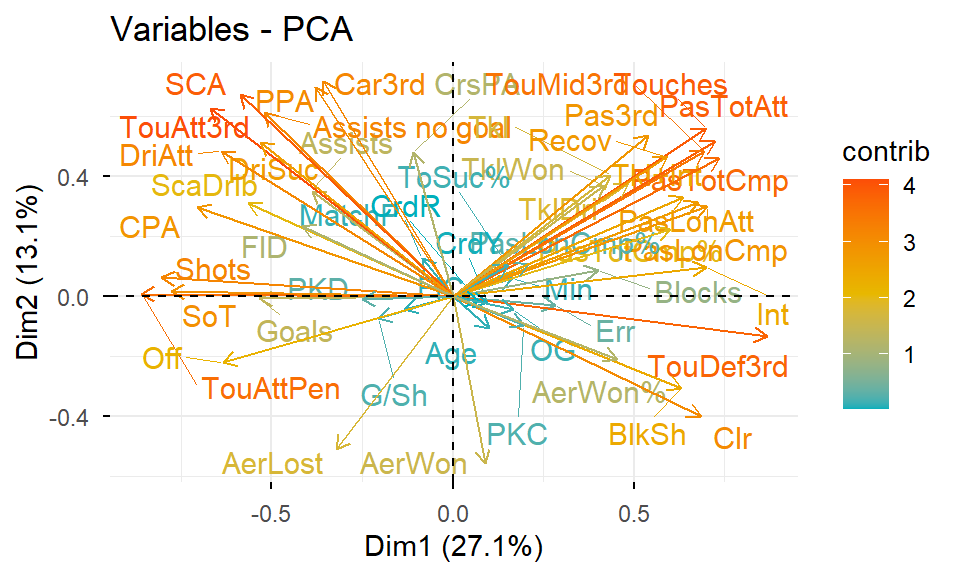

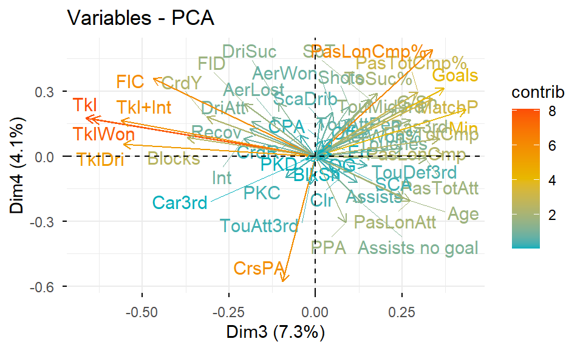

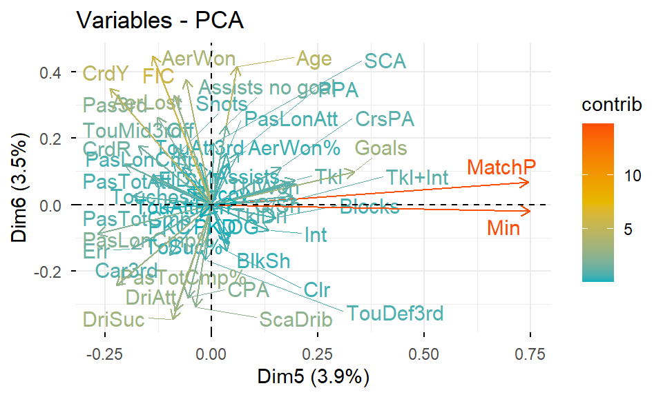

Por tanto, nos centraremos principalmente en las dimensiones que van de la 1 a la 4. Aunque las dimensiones 1 y 2 no parecen estar directamente relacionadas con el valor de mercado, podrían estar reflejando otras características importantes, como el estilo o la posición del jugador. En los siguientes gráficos de scores analizaremos si estas dimensiones permiten diferenciar bien a los jugadores según su posición en el terreno de juego.

## 3.3 Gráficos de scores

Vamos a realizar ahora los gráficos de scores para las diferentes componentes seleccionadas, coloreados por la posición y con la elipse de confianza para cada estantería. Esto lo hacemos con el fin de visualizar cómo se distribuyen los jugadores en el nuevo espacio de componentes principales.

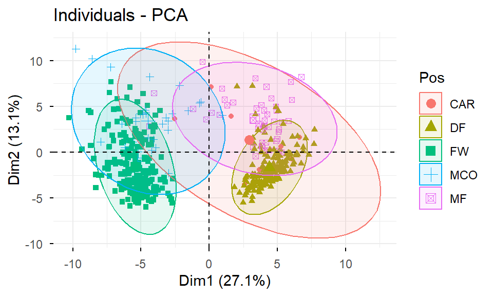

En este gráfico de scores representamos a los jugadores según sus coordenadas en las dos primeras componentes principales del PCA, coloreados por su posición en el campo. Se puede observar que las posiciones se separan bastante bien en el plano formado por Dim1 y Dim2, lo que indica que estas dos primeras componentes explican con éxito la posición del jugador en el campo.

Por ejemplo, los delanteros *(FW)* se agrupan claramente en la parte izquierda, mientras que los defensores *(DF)* lo hacen más hacia la derecha. Los centrocampistas *(MF)* aparecen más centrados, como era de esperar, al estar a medio camino entre tareas defensivas y ofensivas.

También se aprecia un cierto solapamiento entre algunas posiciones, como los carrileros *(CAR)*, que se extienden a lo largo del gráfico ya que su función varía mucho según el sistema de juego (pueden tener tanto un rol ofensivo como defensivo). Los centrocampistas ofensivos *(MCO)* se superponen en parte con los delanteros, lo cual tiene sentido porque muchos de ellos juegan cerca del área rival. A su vez, algunos centrocampistas se solapan con los defensores, reflejando su rol en tareas defensivas como la recuperación de balón.

Este gráfico sugiere que las primeras dos dimensiones del PCA reflejan bastante bien la posición y rol táctico de los jugadores, algo que puede ser muy útil para la interpretación posterior y para los análisis de agrupamiento que haremos más adelante.

A diferencia del gráfico que acabamos de ver, como se anticipaba, en el gráfico de las dimensiones 3 y 4 (*ANEXO 7*) no se aprecia una separación clara entre posiciones. Los grupos se solapan totalmente entre sí, lo que confirma que estas componentes no capturan bien el rol táctico y posicional de los jugadores en el campo.

(Ver Scree Plot en el Anexo 6) (Ver los gráficos de contribución en el Anexo 7 para comprobar qué variables influyen más en cada una de las primeras componentes) (Ver los biplots de las componentes 1–4 en el Anexo 8 para más detalle visual sobre la distribución y orientación de las variables y jugadores).

## 3.4 Validación del Modelo PCA

Después de haber sacado las conclusiones pertinentes al realizar el Análisis de Componentes Principales, procederemos a la validación del modelo PCA, y a comprobar si todo lo que hemos realizado no ha estado condicionado por ningún anómalo que ha alterado nuestros resultados y conclusiones.

Primeramente realizaremos la detección de anómalos con T2-Hotelling (*ANEXO 8*).

El estadístico nos permite identificar valores anómalos extremos, que podrían estar condicionando el modelo, es decir, la creación de las PCs. Este estadístico se calcula a partir de los scores. Por ello, visualizaremos también los gráficos de scores para las PCs seleccionadas, además del gráfico con los valores del T2 tomando las 3 PCs e incluyendo los límites de confianza al 95% y 99%, en naranja y rojo, respectivamente.

Estamos identificando jugadores que se comportan de forma inusual en el espacio de las primeras K componentes principales. Aquellos que tengan un valor de T² superior al umbral del 95% o 99% podrían ser considerados atípicos. Esto es útil para análisis de calidad, detección de errores o exploración de perfiles futbolísticos únicos dentro de nuestro Dataset.

La mayoría de los futbolistas tienen valores de T² entre 0 y 10, por lo que están dentro de la normalidad.

Un grupo pequeño de jugadores superan el umbral y cuentan con una T² > F95, algunos incluso > F99.

Vamos a descubrir quienes son estos jugadores anómalos (*ANEXO 9*):

Solamente 28 jugadores superan el umbral del 99%. No obstante, si leemos atentamente los nombres podemos encontrar jugadores de talla mundial como *Kevin de Bruyne*, *Toni Kroos* o *Kylian Mbappé*. Por otra parte, también encontramos jóvenes promesas como el francés *Rayan Cherki*. Algo que en principio no debería de alarmarnos, ya que son excelsos futbolistas que destacan fuertemente sobre los demás gracias a su juego.

Vamos a generar ahora dos gráficos PCA en paralelo, con los jugadores coloreados según si son atípicos multivariantes fuertes (es decir, si su estadístico Hotelling T² supera el umbral del 99%).

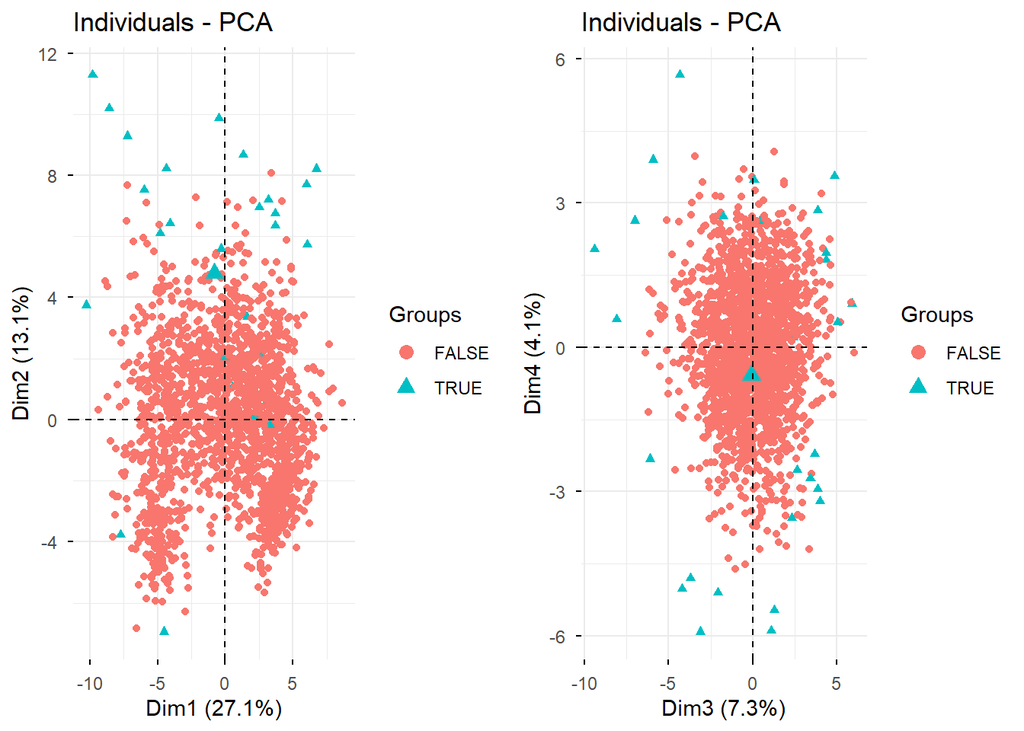

Los futbolistas atípicos se encuentran principalmente alejados del centro de la nube de puntos en las primeras 2 dimensiones, especialmente en dirección positiva de la segunda dimensión (arriba).En el plano de las dimensiones 3 y 4, los “outliers” también tienden a dispersarse lejos del centro, aunque de forma más equilibrada y colándose un individuo en el centro.

Esto indica que las diferencias anómalas de estos jugadores se explican principalmente por las dos primeras dimensiones (que concentran ~40% de la varianza total).

Los jugadores marcados como “TRUE” son casos potencialmente interesantes por su comportamiento extremo en múltiples combinaciones de variables. Esto puede utilizarse para: - Detectar perfiles únicos (p. ej., talentos o rendimientos extremos). - Considerarlos como casos atípicos que influyen en los modelos.

No obstante, mantendremos en el modelo a dichos jugadores porque, dado que estamos estudiando las estadísticas de los futbolistas de las 5 grandes ligas, es lógico que los jugadores con alto rendimiento estén contribuyendo mucho al modelo y no deberíamos excluirlos ya que pueden ayudarnos a entender ,por ejemplo, el valor de mercado, como veremos más adelante.

Por otra parte, podemos emplear el gráfico de contribuciones a la T2 de Hotelling para entender qué variables contribuyen más a que esa observación haya resultado anómala.

Para ello, encontramos que el anómalo máximo es el 1619 -> *Aleksa Terzić* (*ANEXO 10*)

La estadístoca de CrsPA (Centros al área rival completados por partido) es extremadamente alta en comparación con el resto. Está por encima de 12 unidades estandarizadas. Este es el factor principal que explica su carácter atípico.

Otras variables destacadas:

- *PPA* (Pases al área rival): tiene un valor alto.
- *Pas3rd* (Pases al tercio ofensivo): también muy elevado.
- *Assists sin gol* y *SCA* (Acciones que acaban en tiro): por encima del promedio.
- *FlD* (Faltas recibidas) y *AerWon* (duelos aéreos ganados) : también por encima de la media.
- *TouAtt3rd* y *TouAttPen* (toques en el tercio/área ofensiva): son ligeramente elevados.

Por último, variables defensivas *(Tkl, Int, Blocks)* y de disciplina *(tarjetas, penaltis)*, contienen valores bajos o normales.

Con todo esto podemos determinar el perfil del jugador:

*Aleksa Terzić* aparece como un jugador con un comportamiento extremadamente ofensivo en términos de participación en el tercio final y generación de centros al área. Este perfil sugiere que, aunque puede estar clasificado como defensor (lateral), su función dentro del equipo es claramente ofensiva.

En resumen, un lateral con carácter ofensivo, le aporta mucho al ataque de su equipo.

Confirmamos la posición de defensa (lateral), sin embargo, es posible que juegue como lateral ofensivo o directamente carrilero en un sistema de tres centrales.

## 3.5 Distancia al modelo (SCR)

Ahora estudiaremos la distancia al modelo PCA mediante la Suma de Cuadrados Residual (SCR), que nos ayudará a detectar los valores anómalos moderados, es decir, aquellos futbolistas que no están bien explicados por el modelo PCA. Recordemos que los anómalos severos son aquellos detectados con el gráfico T2 de Hotelling pero que presentan una baja SCR.

Para ello, primero calcularemos la matriz de residuos y, a partir de ella, la SCR.

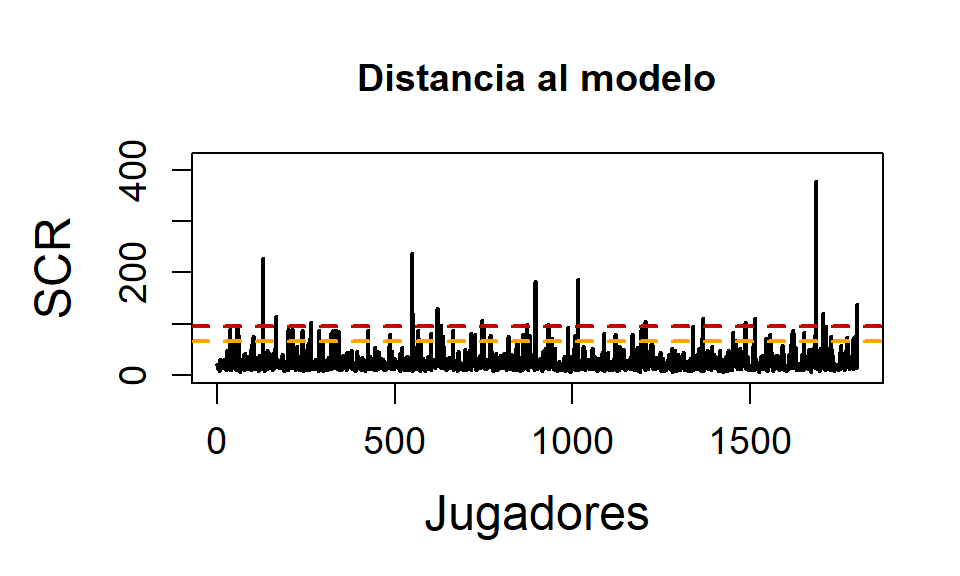

El valor SCR mide qué tan bien se ajusta cada jugador al modelo PCA. Cuanto más alto es el SCR, peor representado está por las componentes seleccionadas.

Los picos altos indican jugadores que no están representados correctamente por las primeras componentes principales.Esto sugiere que tienen patrones únicos o raros que no son capturados por las dimensiones más relevantes del PCA.

A diferencia de la T de Hotelling, no encontramos tantos futbolistas que superen el umbral del 99%, no obstante, hay bastantes que pasan por encima del 95%.

Vamos a descubrir los 10 jugadores que mayor valor de SCR tengan:

```
## # A tibble: 10 × 2
##    Player                     Pos
##    <chr>                      <chr>
##  1 Manu Vallejo               FW
##  2 Carlos Baleba              MF
##  3 Rayan Cherki               MCO
##  4 Nicolás Ezequiel Fernández MF
##  5 Jeremie Boga               MCO
##  6 Ibrahima Konaté            DF
##  7 Lionel Messi               MCO
##  8 José Luis Palomino         DF
##  9 Silvère Ganvoula M'Boussy  FW
## 10 Ronaldo Vieira             MF
```

Nos repetimos como con la T de Hotelling, no vamos a excluir estas variables del estudio, simplemente son jugadores que destacan mucho por sus estadísticas, no tienen datos incorrectos o que no sean reales.

Vamos a ver cómo averiguar qué características tienen estos futbolistas que los hacen diferentes a las tendencias generales resumidas por el modelo PCA. Para ello, vamos a crear una función que calcule las contribuciones de cada variable a la SCR de una observación concreta.

Como ejemplo, generaremos el gráfico de contribuciones para Rayan Cherki, una joven promesa del fútbol frances, que aparece en la lista de los SCR más elevados:

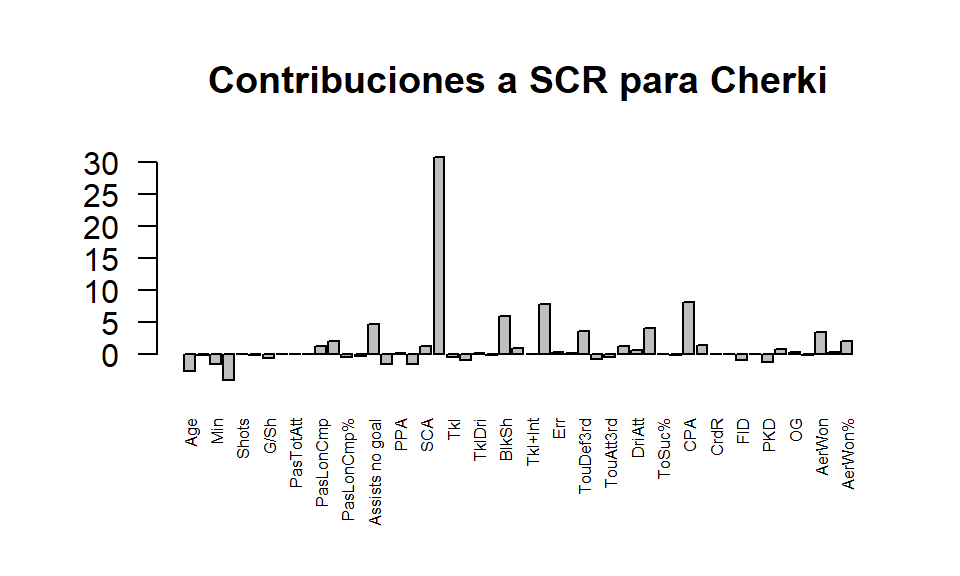

A partir del gráfico de contribuciones al SCR podemos sacar diversas conclusiones:

Las variables que MÁS contribuyen POSITIVAMENTE, estas son las que causan atipicidad:

- *ScaDrib* (regates exitosos que acaban en tiro), es claramente la variable dominante.

Este jovencísimo francés se distingue por realizar numerosos regates que generan tiros, lo que lo aleja del comportamiento promedio. Este es el factor principal de su carácter atípico.

También le ayudan a caracterizarse:

- *BlkSh* (tiros bloqueados por partido) y *Clr* (despejes por partido), sugieren que tiene también un papel activo en acciones defensivas, poco común en perfiles ofensivos.
- *Assists no goal* (asistencias que acaban en tiro, aunque no en gol), estadística que refuerza aún más su rol de creador de ocasiones, incluso más allá de las asistencias directas.

Por otra parte tenemos las variables con contribución NEGATIVA (representadas bien en el modelo): Estas variables ayudan a reducir su SCR, es decir, no contribuyen a su anormalidad. Tienen valores coherentes con el patrón general del conjunto:

- *Age*: es joven, pero no excepcional en comparación con otros.
- *Min* (minutos jugados) negativo: puede que no haya jugado muchos, como muchos jóvenes.
- *Goals*: valor típico, marca goles pero no destaca por ello.
- *Pas3rd* (pases al tercio ofensivo): comportamiento estándar.

Todo esto consolida a Cherki como un jugador híbrido, creativo y participativo en defensa, lo que explica que el modelo PCA no logre captarlo bien en pocas dimensiones.

## 3.6 Conclusión sobre la validación del modelo PCA

Los resultados muestran que el modelo capta adecuadamente la estructura general de los datos, y que la mayoría de los jugadores se encuentran bien representados en el espacio reducido de componentes principales.

Los casos que presentan valores atípicos en T² o SCR no corresponden a errores o problemas de modelado, sino que reflejan perfiles de jugadores extraordinarios, ya sea por un estilo de juego particularmente ofensivo, defensivo o híbrido, o bien por métricas singulares que los hacen sobresalir del patrón común. Es decir, se trata de futbolistas que simplemente se salen de la norma y, por tanto, aportan valor al análisis como ejemplos de diversidad en el rendimiento.

# 4 Análisis Factorial de Correspondencias (AFC)

Aplicar un Análisis Factorial de Correspondencias (AFC) en este proyecto no sería una decisión adecuada, ya que esta técnica no se ajusta al tipo de datos ni a los objetivos planteados en el estudio. El AFC está diseñado específicamente para explorar relaciones entre variables categóricas, es decir, variables que representan grupos o etiquetas como la nacionalidad, la liga o la posición del jugador. En este trabajo, sin embargo, el análisis gira en torno a un conjunto amplio de variables numéricas que reflejan directamente el rendimiento de los futbolistas durante la temporada, como goles, minutos jugados, asistencias, disparos, entradas o regates. El AFC, al centrarse únicamente en variables cualitativas, no permite analizar adecuadamente este tipo de información, por lo que su uso no contribuiría a alcanzar ninguno de los objetivos del proyecto. Además, aunque el conjunto de datos incluye algunas variables categóricas, estas no son el eje central del análisis, sino que actúan más bien como contexto o referencia. Por tanto, aplicar un AFC desviaría el enfoque metodológico y no aportaría resultados útiles ni relevantes dentro de la lógica del trabajo.

# 5 Clustering

Ahora pasaremos a realizar el clustering.

El objetivo de este es encontrar grupos de futbolistas con características similares en su rendimiento o perfil técnico, gracias a sus estadísticas. Para ello, utilizaremos en el análisis de clustering únicamente las variables numéricas relacionadas con el desempeño y atributos futbolísticos. Posteriormente, intentaremos relacionar los clústeres obtenidos con variables externas, como por ejemplo la posición, el equipo, o la nacionalidad.

Dado que cada variable está medida en diferentes escalas y unidades (por ejemplo, goles, tiros, pases, etc.), usaremos los datos que ya tenemos centrados y escalados de la parte del PCA. Esto es esencial para evitar que las variables de mayor magnitud dominen la estructura de agrupación y asegurar que todas contribuyen de forma equilibrada al proceso de clustering.

Se utilizará la distancia euclídea como medida de distancia, ya que nos interesa agrupar futbolistas con valores similares en sus estadísticas de rendimiento y atributos técnicos. Al estar los datos centrados y escalados, la distancia euclídea permite que todas las variables aporten de forma equilibrada.

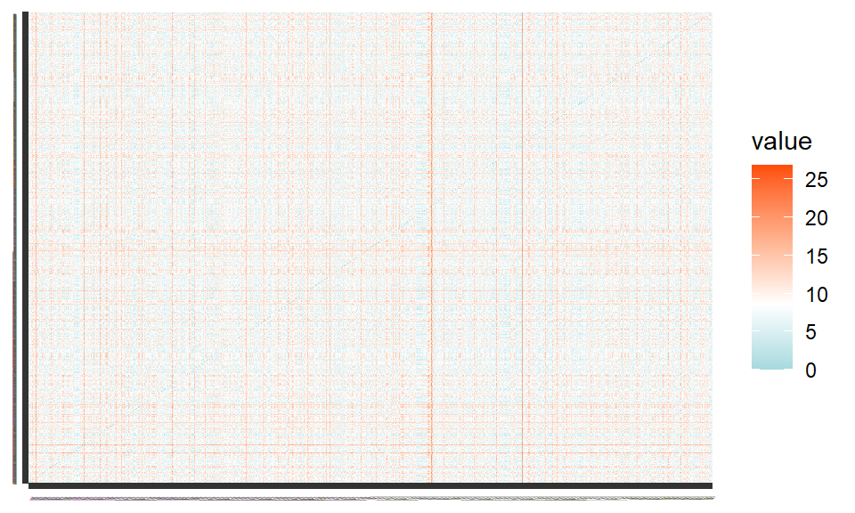

El estadístico de Hopkins nos confirma una cierta tendencia de agrupamiento, puesto que ha sido calculado para diferentes valores de m (n en la función) y con diferentes semillas aleatorias y sus valores oscilan entre 0.79 y 0.81, es decir, están cercanos a 1. (*ANEXO 13*)

## 5.1 MODELOS JERÁRQUICOS

### 5.1.1 MÉTODO DE WARD

En primer lugar, aplicaremos modelos jerárquicos, utilizando el método de Ward y el método de la media. Empezaremos por estimar el número óptimo de clusters:

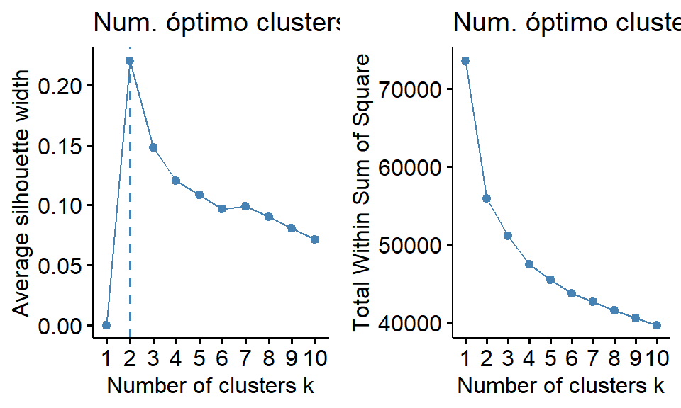

Aunque los métodos sugieren 2 clusters como óptimo, consideramos que este número es insuficiente para captar la diversidad de perfiles futbolísticos presentes en los datos. Observando los gráficos, optar por 3 o 4 clusters resulta un compromiso adecuado entre calidad estadística y riqueza interpretativa, ya que el índice de silueta y la reducción de la WSS siguen siendo razonables, permitiendo además extraer conclusiones más detalladas sobre los diferentes tipos de jugadores. Generamos, pues, los 4 clusters.

```
## grupos1
##   1   2   3   4
## 486 382 690 242
```

No realizamos el dendograma, debido a que contamos con demasiados jugadores, no llega a aportar ni información y sería excesivamente complicado interpretarlo visualmente.

El método de la media lo descartamos ya que a mayoría de jugadores han sido agrupados en un solo cluster.(*Anexo 14*)

## 5.2 MÉTODOS DE PARTICIÓN

### 5.2.1 K-MEDIAS

En primer lugar, aplicaremos el algoritmo de k-medias y determinaremos el número óptimo de clusters para este algoritmo.

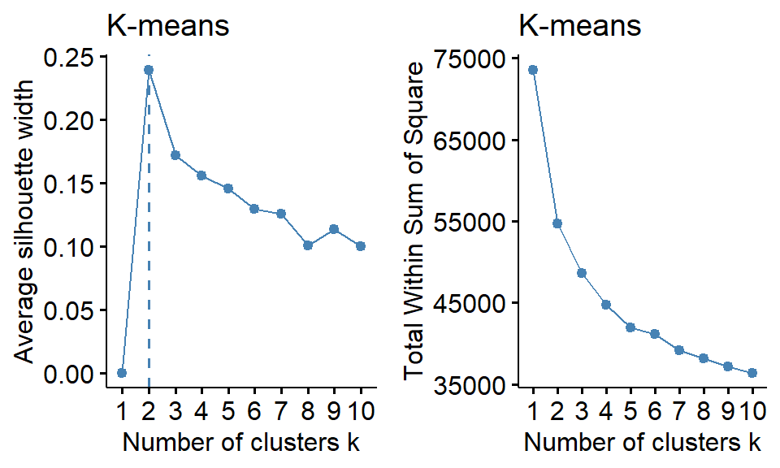

Aunque estadísticamente el número óptimo de clusters según Silhouette es 2, la reducción significativa de la WSS hasta 3 o 4 clusters y la aceptable calidad de la agrupación sugieren que elegir 3 o 4 clusters es una opción razonable si buscamos un mayor nivel de segmentación e interpretabilidad en los perfiles de futbolistas. Por tanto, optar por 3 o 4 clusters nos ofrece un buen compromiso entre calidad estadística y riqueza descriptiva del análisis. Tambíen utilizamos otra alternativa con la librería NbClust.(*ANEXO 15*)

Generamos, pues, los 3 clusters.

```
##
##   1   2   3
## 421 796 583
```

### 5.2.2 K-MEDOIDES

Probaremos como última opción el método de los k-medoides que debería ser más robusto frente a los valores atípicos. Determinaremos, en primer lugar, el número óptimo de clusters.

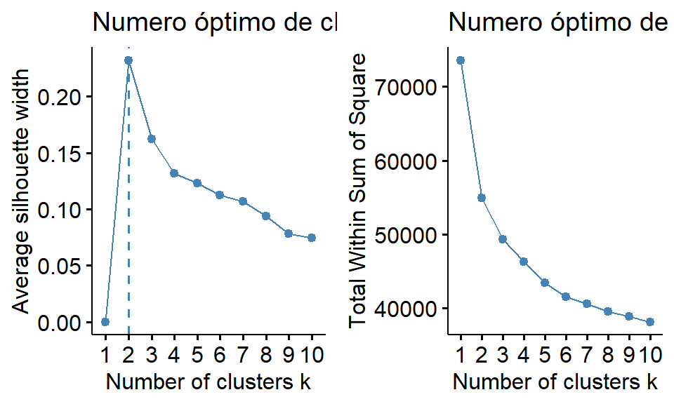

[output not shown]

Aunque el criterio estadístico óptimo es 2 clusters según ambos métodos, como buscamos mayor segmentación e interpretabilidad (para diferenciar más perfiles futbolísticos), 4 o 5 clusters siguen siendo opciones razonables, ya que no hay una caída brusca en la calidad y el descenso de la silueta es progresivo. Así, con k-medoides, la solución de 2 clusters es la más robusta, pero 4 o 5 pueden considerarse válidas si se prioriza la riqueza descriptiva sobre la máxima calidad estadística del agrupamiento. Los generamos:

```
##
##   1   2   3   4
## 498 411 542 349
```

## 5.3 SELECCIÓN Y VALIDACIÓN DEL MÉTODO

A la vista de los resultados anteriores, es difícil decantarse por un método en concreto ya que ofrecen resultados similares en algunos casos.

Para tomar una decisión, analizaremos en primer lugar el coeficiente de Silhouette por cluster y por observación (no solamente el global como hasta ahora):

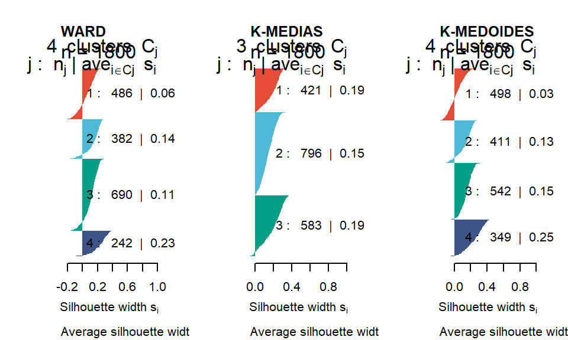

K-medias presenta la mejor estructura de agrupamiento global, con mayor coherencia y separación entre grupos (mayor Silhouette promedio y menos valores negativos). Ward y K-medoides muestran una mayor heterogeneidad interna y algunos clusters con baja calidad, aunque en ambos casos existe al menos un grupo pequeño con buena silueta. Optamos por K-medias con 3 clusters.

Elegiremos, pues, el método de k-medias y conservamos los 3 clusters

## 5.4 INTERPRETACIÓN DE LOS RESULTADOS DEL CLUSTERING

En primer lugar, vamos a realizar un análisis de PCA completo para ver cuáles de las variables utilizadas en el clustering han contribuido más a la determinación de los clusters obtenidos mediante k-medias. (*ANEXO 16*)

Las componentes principales 3 y 4 recogen variabilidad residual que no es útil para separar los clusters principales. La mayor parte de la información útil para la segmentación de los jugadores ya se encontraba en las componentes 1 y 2.

Para complementar o ayudar a la interpretación anterior de los clusters mediante PCA, vamos a realizar un gráfico descriptivo del perfil de cada cluster para observar las diferencias entre ellos. Para ello, calcularemos la media de cada variable para cada cluster.(*ANEXO 17*)

El análisis de los perfiles medios de cada cluster revela tres grandes grupos de jugadores:

El Cluster 1 se asocia principalmente a roles defensivos, sobresaliendo en estadísticas de despejes, bloqueos y duelos aéreos, pero con escasa contribución en ataque. El Cluster 2 agrupa jugadores de perfil mixto o mediocampistas, con valores equilibrados tanto en acciones defensivas como en la circulación y recuperación del balón. El Cluster 3 representa a los jugadores ofensivos, con altas medias en goles, remates y acciones de ataque, pero una menor implicación en aspectos defensivos.

[figure not shown]

En concreto, otras observaciones que vemos son:

El valor de mercado es mayor en c3 (ofensivos), intermedio en c2, y menor en c1 (defensivos), lo que suele ser esperado en el fútbol profesional. Respecto a la edad, apenas hay diferencias notorias, pero c1 tiene una ligera tendencia a mayor edad. Si nos fijamos en los minutos y partidos c1 juega más minutos en promedio, c3 menos.

```
##   misclust valor_mercado
## 1        1      10.12779
## 2        2      10.87343
## 3        3      14.36235
```

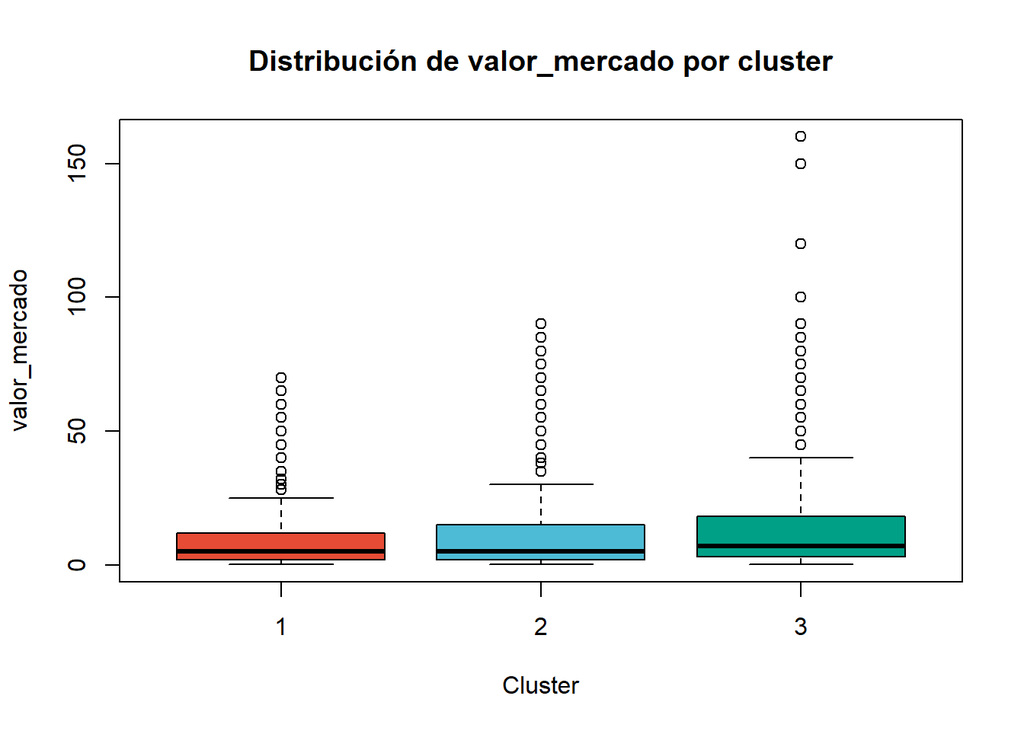

```
##   misclust         Age
## 1        1  0.13335668
## 2        2 -0.02036656
## 3        3 -0.06849294
```

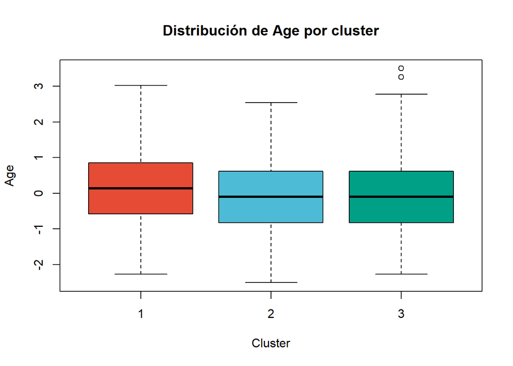

```
##   misclust         Min
## 1        1  0.25459884
## 2        2  0.01253477
## 3        3 -0.20096705
```

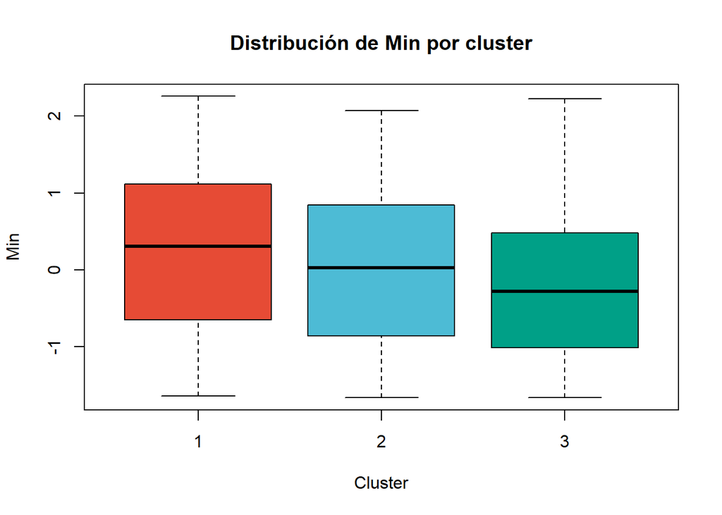

# 6 Reglas de Asociación

No se han utilizado reglas de asociación en este proyecto porque no encajan con el tipo de estudio que se está realizando ni con el tipo de información con el que se está trabajando. Este tipo de técnica se emplea principalmente para descubrir relaciones frecuentes entre variables categóricas, como por ejemplo “si un jugador pertenece a cierto equipo y tiene cierta posición, entonces también suele cometer muchas faltas”. Sin embargo, el enfoque del proyecto está centrado en variables numéricas que reflejan el rendimiento deportivo, tales como goles, asistencias, tiros, intercepciones, minutos jugados, entre muchas otras. Además, los objetivos del estudio requieren herramientas estadísticas que no solo identifiquen patrones de aparición conjunta, sino que permitan modelar, clasificar y predecir comportamientos a partir de datos cuantitativos. Las reglas de asociación no están pensadas para ese tipo de análisis, ya que no trabajan con variables continuas ni ofrecen información sobre la influencia o el peso de cada variable en el resultado. Por todo ello, aplicar reglas de asociación en este proyecto no solo resultaría poco útil, sino que además no aportaría información relevante para los objetivos planteados.

# 7 Análisis Discriminante

En el desarrollo de este proyecto, uno de los objetivos principales ha sido identificar de manera clara y fundamentada cómo las distintas estadísticas de juego de los futbolistas pueden estar relacionadas con su nivel de valor en el mercado. Para abordar este objetivo, se ha optado por aplicar un Análisis Discriminante Lineal (LDA), una técnica estadística multivariante que resulta especialmente útil cuando se pretende clasificar observaciones en categorías previamente definidas en función de múltiples variables predictoras.

El motivo principal por el que se ha elegido este enfoque es que se dispone de una variable categórica que representa el nivel de valor de mercado del jugador —clasificado en tres grupos: bajo, medio y alto— y se busca comprobar si las demás variables cuantitativas (como goles, minutos, asistencias, pases, regates, entre otras) pueden discriminar de forma significativa entre estas categorías. Es decir, se pretende averiguar si existe una estructura en los datos que permita predecir el valor de mercado de un jugador a partir de su rendimiento estadístico.

El análisis discriminante resulta adecuado porque, además de clasificar, permite obtener funciones discriminantes que muestran qué combinaciones de variables explican mejor la separación entre grupos. Estas funciones no solo ayudan a construir un modelo predictivo, sino que también ofrecen información interpretativa sobre cuáles son las variables más influyentes en la diferenciación de los grupos definidos.

Además, se ha considerado que esta técnica puede facilitar la visualización de la separación entre las clases, lo cual puede ser útil tanto para validar el modelo como para comunicar los resultados de forma clara. Al proyectar los datos sobre las funciones discriminantes (LD1, LD2…), se puede representar gráficamente hasta qué punto los grupos se separan entre sí, y si la segmentación realizada tiene sentido desde el punto de vista estadístico y práctico.

Por otra parte, como paso previo a la aplicación del análisis discriminante, se ha realizado una agrupación de los valores de mercado mediante k-means, con el fin de construir la variable categórica que será utilizada como criterio de clasificación. Esta decisión permite transformar una variable continua (el valor económico del jugador) en una variable categórica más adecuada para el análisis que se quiere realizar.

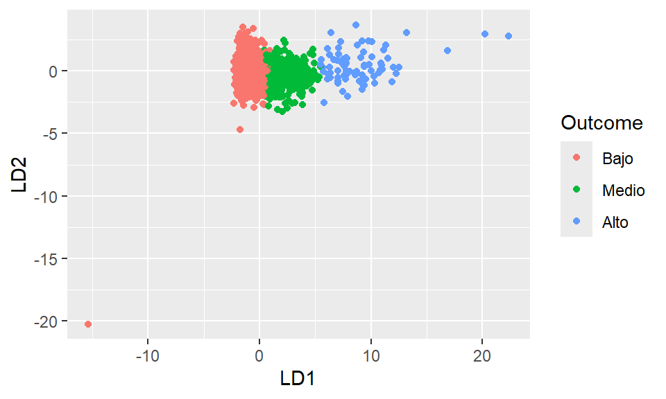

## 7.1 Resultados del análisis discriminante

El modelo desarrollado para clasificar a los jugadores según su valor de mercado ha mostrado un desempeño muy sólido (*ANEXO 18*). En el gráfico, se observa claramente cómo los tres grupos (Bajo, Medio y Alto) están bien separados, sobre todo en el eje horizontal (LD1), que es el que más ayuda a distinguir entre los niveles. Los jugadores de valor bajo se agrupan a la izquierda, los de nivel medio en el centro, y los de valor alto a la derecha, formando tres zonas bien definidas. Esto indica que las características de los jugadores son lo suficientemente distintas como para que el modelo pueda clasificarlos de forma precisa.

En cuanto a los resultados numéricos, la precisión del modelo alcanza un 97.36% en el conjunto de entrenamiento y un 96.66% en los datos de prueba, lo cual confirma que el modelo no solo aprende bien con los datos que ha visto, sino que también mantiene un buen rendimiento con datos nuevos. La puntuación Kappa, que mide la calidad del modelo teniendo en cuenta el azar, es muy alta: 0.9261 en entrenamiento y 0.9048 en prueba. Estos valores indican que el modelo tiene una capacidad de clasificación muy confiable.

Al observar con más detalle las medidas por grupo, se ve que la sensibilidad (es decir, la capacidad del modelo para detectar correctamente a los jugadores de cada categoría) es perfecta para los de valor bajo, bastante alta para los de nivel medio (alrededor de 85%) y también muy buena para los de valor alto (entre 86% y 95%). Además, la especificidad (es decir, cuán bien el modelo evita confundirlos con otras clases) es muy alta para todos los grupos, alcanzando incluso el 100% en el caso de los jugadores de valor alto.

Esto se ve reflejado en la matriz de confusión, donde prácticamente no hay errores: por ejemplo, ningún jugador de valor bajo fue confundido con uno de valor alto, y los errores más comunes ocurren entre las clases “Bajo” y “Medio”, lo cual es esperable, ya que estos grupos tienen perfiles más parecidos.

En cuanto a las características que más influyen en la clasificación, se observa que los jugadores de valor alto destacan especialmente en acciones ofensivas: tienen más minutos jugados, más goles, más asistencias, más disparos, más toques en el tercio ofensivo y en el área rival, más regates y más participaciones en jugadas de gol. También se mueven más en zonas avanzadas del campo y tienen mejor rendimiento en estadísticas como precisión de pases largos, centros al área y pases completados.

Por el contrario, los jugadores de valor bajo tienden a tener menor participación ofensiva y destacan menos en estadísticas de creación de juego o definición. En general, su perfil está más asociado a tareas defensivas o menos visibles, aunque estas tienen menos peso a la hora de determinar el valor de mercado.

Finalmente, cuando se analiza la probabilidad con la que el modelo asigna una categoría a cada jugador, se ve que en la mayoría de los casos está muy seguro. Por ejemplo, hay jugadores para los que la probabilidad de estar en la categoría “Bajo” supera el 99%, lo que demuestra que su perfil es muy claro. Solo en algunos pocos casos hay algo de duda entre dos clases, sobre todo entre las categorías “Bajo” y “Medio”.

En conjunto, todos estos resultados muestran que el modelo no solo es muy preciso, sino también coherente: reconoce correctamente a los jugadores según su rendimiento y logra diferenciar claramente a los de mayor valor de mercado, que suelen tener un perfil ofensivo más destacado.

# 8 Regresión PLS

## 8.1 Análisis PLS para los goles

A continuación, se realizará un análisis de regresión PLS (Partial Least Squares) para modelar y los goles de los jugadores a partir de sus variables numéricas. El objetivo es identificar qué combinación de variables explica mejor la variabilidad en la cantidad de goles y evaluar la capacidad predictiva del modelo.

## 8.2 Estimación del modelo y optimización del número de componentes

Primero, seleccionamos las variables numéricas (menos los goles) como predictores (X) y los goles como variable respuesta (Y). Esto nos permitirá ajustar el modelo PLS para predecir el número de goles a partir de las estadísticas de los jugadores. Ajustamos el modelo PLS utilizando la función opls, que selecciona automáticamente el número óptimo de componentes mediante validación cruzada leave-one-out.

```
## PLS
## 1800 samples x 51 variables and 1 response
## standard scaling of predictors and response(s)
##       R2X(cum) R2Y(cum) Q2(cum) RMSEE pre ort pR2Y  pQ2
## Total    0.442     0.67   0.646  1.33   4   0 0.05 0.05
```

El modelo PLS ajustado para predecir los goles de los jugadores muestra un ajuste y capacidad predictiva adecuados: R2X(cum) = 0.442 indica que el modelo explica el 44.2% de la variabilidad de las variables predictoras, mientras que R2Y(cum) = 0.67 muestra que el 67% de la variabilidad en el número de goles es explicada por el modelo. El valor Q2(cum) = 0.647 refleja una buena capacidad predictiva mediante validación cruzada y RMSEE = 1.33 indica un error de predicción moderado. El modelo utiliza 4 componentes latentes (pre = 4) y los valores ort, pR2Y y pQ2 (0, 0.05, 0.05) sugieren ausencia de sobreajuste y buena robustez. En resumen, el modelo PLS explica de forma razonable el número de goles a partir de las estadísticas de los jugadores, mostrando un equilibrio entre ajuste e interpretabilidad. De cualquier manera, vamos a generar nuestro propio gráfico para estimar mejor el número óptimo de componentes del modelo.

```
## PLS
## 1800 samples x 51 variables and 1 response
## standard scaling of predictors and response(s)
##       R2X(cum) R2Y(cum) Q2(cum) RMSEE pre ort pR2Y  pQ2
## Total    0.631    0.693   0.599  1.29  10   0 0.05 0.05
```

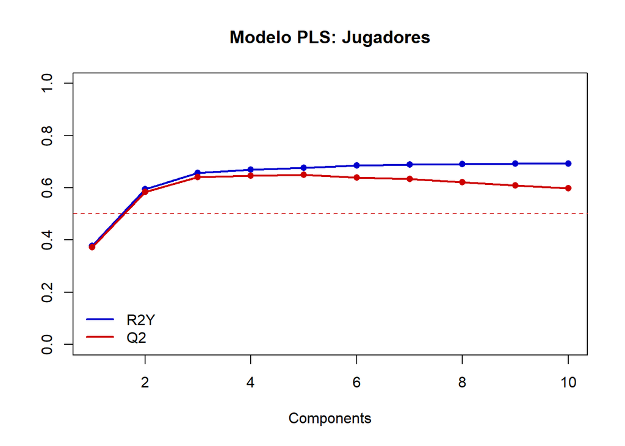

El gráfico muestra cómo los valores de R2Y (ajuste del modelo) y Q2 (capacidad predictiva) aumentan rápidamente hasta la tercera componente y luego se estabilizan, superando ampliamente el umbral de 0.5. Esto indica que, a partir de la tercera componente, añadir más componentes no mejora significativamente el modelo.

Por todo esto, nos quedamos únicamente con las tres primeras componentes principales, volvemos a generar el modelo pero esta vez con 3. (*ANEXO 19*)

En conclusión, aunque el modelo con cuatro componentes presenta un ajuste ligeramente superior (R2Y = 0.670, Q2 = 0.647, RMSEE = 1.33), la versión con tres componentes ofrece un rendimiento muy similar (R2Y = 0.658, Q2 = 0.642, RMSEE = 1.35), con la ventaja de ser más simple e interpretable. La pérdida de capacidad explicativa y predictiva es mínima, mientras que se gana en parsimonia y estabilidad. Por tanto, el modelo PLS con tres componentes se considera más adecuado ya que mantiene un buen equilibrio entre rendimiento y simplicidad.

## 8.3 Validación del modelo

### 8.3.1 Validación del modelo PLS

La validación del modelo es un proceso fundamental para evaluar la capacidad predictiva y la robustez del modelo ajustado. Consiste en comprobar que el modelo no solo se ajusta bien a los datos de entrenamiento, sino que también generaliza correctamente a nuevos datos. En este caso, la validación se realiza principalmente mediante la evaluación de los valores de R² y Q², así como la interpretación gráfica de los scores y las relaciones entre componentes. No se realizará una detección adicional de valores atípicos o anómalos en esta etapa, ya que dicho análisis ya fue llevado a cabo previamente durante el preprocesamiento con el PCA, donde se identificaron y trataron las observaciones anómalas.

Empezaremos analizando la relación lineal entre los scores (t) y las variables u para cada componente.

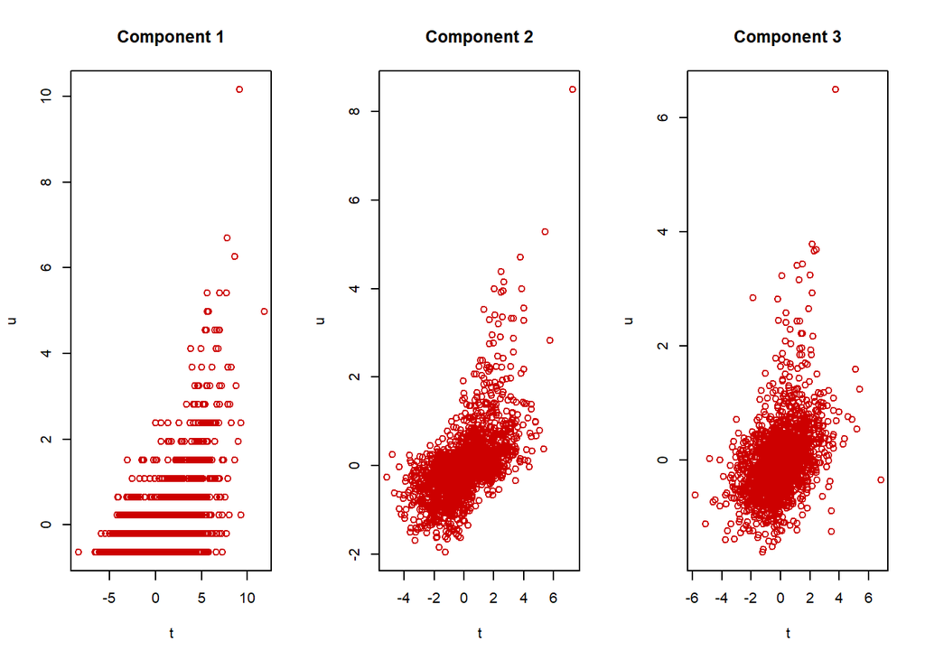

```
##        p1        p2        p3
## 0.6145182 0.5916388 0.3925488
```

Las correlaciones obtenidas muestran que existe una relación lineal moderada entre los scores (t) y las variables u en las dos primeras componentes (correlaciones = 0.61 y 0.59), mientras que en la tercera componente la relación es más débil (correlación = 0.39). Esto indica que las dos primeras componentes capturan la mayor parte de la relación lineal entre las variables predictoras y la respuesta, mientras que la tercera componente aporta información adicional pero menos relevante.

Además, se realiza un cálculo más detallado del R² y Q², tanto acumulado como por variable, para evaluar en profundidad la capacidad explicativa y predictiva del modelo PLS. Esto permite identificar qué variables contribuyen más a la explicación y predicción de la variable respuesta (goles), y cómo evoluciona la calidad del modelo al añadir componentes.

Para ello, se utiliza la función R2, que calcula el R² por variable y total, y se aplica sobre las matrices de predicción de X y Y generadas por el modelo PLS. Asimismo, se calcula Q² mediante validación cruzada, obteniendo así una visión más granular del rendimiento del modelo para cada variable y componente.

Los resultados se visualizan mediante gráficos de barras apiladas, mostrando la contribución de cada componente al R² por variable, y permitiendo identificar las variables más relevantes en la explicación de la respuesta. (*ANEXO 20*)

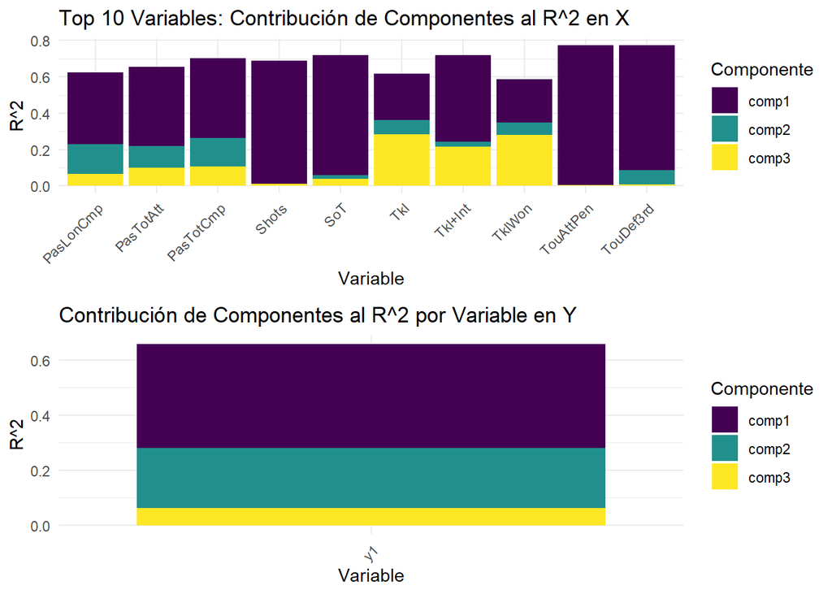

Además, se aprecia que ciertas variables, como por ejemplo las relacionadas con la defensa o el juego aéreo, presentan una mayor contribución explicada por la segunda o tercera componente en lugar de la primera. Esto sugiere que estas variables capturan aspectos del rendimiento que no están directamente asociados con la dimensión principal del modelo, sino que requieren componentes adicionales para ser explicadas adecuadamente. Así, el modelo PLS permite descomponer la variabilidad en diferentes ejes latentes, facilitando la interpretación de cómo distintos grupos de variables se asocian a diferentes patrones de juego.

En el segundo gráfico, la contribución de los componentes al R² en la variable respuesta (goles) muestra que la mayor parte de la variabilidad explicada se concentra en la primera componente, con aportes adicionales de la segunda y tercera. Esto sugiere que la relación entre las estadísticas individuales y el número de goles puede ser capturada de manera eficiente con pocas componentes latentes.

## 8.4 Medidas del error en la predicción

```
## [1] 1.353435
```

```
## [1] 0.9080069
```

El valor obtenido para el error cuadrático medio de predicción (myRMSE = 1.35) indica que, en promedio, la diferencia entre los goles reales y los predichos por el modelo PLS es de aproximadamente 1.35 goles por jugador. Además, el coeficiente de variación del error (CVrmse = 0.91) muestra que el error representa cerca del 91% de la media de goles, lo que sugiere que, aunque el modelo capta ciertas tendencias generales, su capacidad predictiva individual es limitada y existe un margen considerable de mejora en la precisión de las predicciones.

En conclusión, el análisis PLS realizado sobre las estadísticas de los jugadores ha permitido identificar las variables numéricas que más contribuyen a explicar y predecir el número de goles. El modelo muestra un ajuste razonable y una capacidad predictiva aceptable, aunque con margen de mejora, como reflejan los valores de R² y Q² y el coeficiente de variación del error. Las primeras componentes latentes capturan la mayor parte de la relación entre las estadísticas individuales y el rendimiento goleador, destacando especialmente las variables ofensivas como las más influyentes. Sin embargo, el error relativo respecto a la media de goles indica que, si bien el modelo capta tendencias generales, su precisión a nivel individual es limitada. En conjunto, el PLS proporciona una visión clara de los factores clave asociados al rendimiento goleador y constituye una base sólida para futuras mejoras o análisis complementarios.

# 9 Anexos

## 9.1 ANEXO 1

```
## [1] 1800   57
```

```
## # A tibble: 3 × 57
##   Player   Nation Pos   Team  League   Age MatchP   Min Goals Shots   SoT `G/Sh`
##   <chr>    <chr>  <chr> <chr> <chr>  <dbl>  <dbl> <dbl> <dbl> <dbl> <dbl>  <dbl>
## 1 Brenden… USA    MCO   Leed… Premi…    22     20  1596     1  1.53  0.28   0.04
## 2 Yunis A… MAR    DF    Reims Ligue…    35     22  1980     0  0.86  0.05   0
## 3 Himad A… FRA    MCO   Ange… Ligue…    23     14   770     0  1.05  0.35   0
## # ℹ 45 more variables: PasTotCmp <dbl>, PasTotAtt <dbl>, `PasTotCmp%` <dbl>,
## #   PasLonCmp <dbl>, PasLonAtt <dbl>, `PasLonCmp%` <dbl>, Assists <dbl>,
## #   `Assists no goal` <dbl>, Pas3rd <dbl>, PPA <dbl>, CrsPA <dbl>, SCA <dbl>,
## #   ScaDrib <dbl>, Tkl <dbl>, TklWon <dbl>, TklDri <dbl>, Blocks <dbl>,
## #   BlkSh <dbl>, Int <dbl>, `Tkl+Int` <dbl>, Clr <dbl>, Err <dbl>,
## #   Touches <dbl>, TouDef3rd <dbl>, TouMid3rd <dbl>, TouAtt3rd <dbl>,
## #   TouAttPen <dbl>, DriAtt <dbl>, DriSuc <dbl>, `ToSuc%` <dbl>, …
```

```
##     Player             Nation              Pos                Team
##  Length:1800        Length:1800        Length:1800        Length:1800
##  Class :character   Class :character   Class :character   Class :character
##  Mode  :character   Mode  :character   Mode  :character   Mode  :character
##
##
##
##     League               Age            MatchP           Min
##  Length:1800        Min.   :16.00   Min.   : 5.00   Min.   : 202.0
##  Class :character   1st Qu.:23.00   1st Qu.:12.00   1st Qu.: 576.5
##  Mode  :character   Median :26.00   Median :16.00   Median : 986.0
##                     Mean   :26.44   Mean   :15.26   Mean   : 994.9
##                     3rd Qu.:29.00   3rd Qu.:19.00   3rd Qu.:1383.0
##                     Max.   :41.00   Max.   :23.00   Max.   :2069.0
##      Goals            Shots            SoT              G/Sh
##  Min.   : 0.000   Min.   :0.000   Min.   :0.0000   Min.   :0.00000
##  1st Qu.: 0.000   1st Qu.:0.500   1st Qu.:0.1000   1st Qu.:0.00000
##  Median : 1.000   Median :1.040   Median :0.3000   Median :0.05000
##  Mean   : 1.491   Mean   :1.296   Mean   :0.4291   Mean   :0.08086
##  3rd Qu.: 2.000   3rd Qu.:1.930   3rd Qu.:0.6700   3rd Qu.:0.13000
##  Max.   :25.000   Max.   :5.550   Max.   :2.5000   Max.   :1.00000
##    PasTotCmp      PasTotAtt        PasTotCmp%      PasLonCmp
##  Min.   : 0.0   Min.   :  0.00   Min.   : 0.00   Min.   : 0.000
##  1st Qu.:23.9   1st Qu.: 32.98   1st Qu.:72.10   1st Qu.: 1.520
##  Median :33.9   Median : 43.80   Median :78.30   Median : 2.750
##  Mean   :34.9   Mean   : 44.15   Mean   :77.12   Mean   : 3.155
##  3rd Qu.:44.1   3rd Qu.: 54.33   3rd Qu.:83.30   3rd Qu.: 4.440
##  Max.   :97.2   Max.   :104.20   Max.   :95.50   Max.   :13.000
##    PasLonAtt        PasLonCmp%        Assists        Assists no goal
##  Min.   : 0.000   Min.   :  0.00   Min.   :0.00000   Min.   :0.0000
##  1st Qu.: 2.835   1st Qu.: 47.50   1st Qu.:0.00000   1st Qu.:0.3975
##  Median : 5.115   Median : 57.10   Median :0.05000   Median :0.8300
##  Mean   : 5.494   Mean   : 56.69   Mean   :0.09397   Mean   :0.9358
##  3rd Qu.: 7.612   3rd Qu.: 66.70   3rd Qu.:0.15000   3rd Qu.:1.3400
##  Max.   :20.600   Max.   :100.00   Max.   :1.14000   Max.   :5.0600
##      Pas3rd            PPA             CrsPA             SCA
##  Min.   : 0.000   Min.   :0.0000   Min.   :0.0000   Min.   :0.000
##  1st Qu.: 1.570   1st Qu.:0.3100   1st Qu.:0.0000   1st Qu.:1.220
##  Median : 2.540   Median :0.6700   Median :0.1100   Median :2.050
##  Mean   : 2.838   Mean   :0.7837   Mean   :0.2058   Mean   :2.179
```

[output cut: 50 more lines]

```
##  Max.   :2.8000   Max.   :0.87000   Max.   :0.48000   Max.   :0.2900
##      Recov            AerWon          AerLost         AerWon%
##  Min.   : 0.000   Min.   : 0.000   Min.   :0.000   Min.   :  0.00
##  1st Qu.: 4.100   1st Qu.: 0.560   1st Qu.:0.790   1st Qu.: 33.30
##  Median : 5.200   Median : 1.075   Median :1.180   Median : 47.80
##  Mean   : 5.165   Mean   : 1.342   Mean   :1.424   Mean   : 46.04
##  3rd Qu.: 6.260   3rd Qu.: 1.810   3rd Qu.:1.740   3rd Qu.: 58.30
##  Max.   :11.300   Max.   :14.500   Max.   :9.400   Max.   :100.00
##  valor_mercado
##  Min.   :  0.15
##  1st Qu.:  2.15
##  Median :  6.00
##  Mean   : 11.83
##  3rd Qu.: 15.00
##  Max.   :160.00
```

## 9.2 ANEXO 2

```
##       Age            MatchP           Min             Goals
##  Min.   :16.00   Min.   : 5.00   Min.   : 202.0   Min.   : 0.000
##  1st Qu.:23.00   1st Qu.:12.00   1st Qu.: 576.5   1st Qu.: 0.000
##  Median :26.00   Median :16.00   Median : 986.0   Median : 1.000
##  Mean   :26.44   Mean   :15.26   Mean   : 994.9   Mean   : 1.491
##  3rd Qu.:29.00   3rd Qu.:19.00   3rd Qu.:1383.0   3rd Qu.: 2.000
##  Max.   :41.00   Max.   :23.00   Max.   :2069.0   Max.   :25.000
##      Shots            SoT              G/Sh           PasTotCmp
##  Min.   :0.000   Min.   :0.0000   Min.   :0.00000   Min.   : 0.0
##  1st Qu.:0.500   1st Qu.:0.1000   1st Qu.:0.00000   1st Qu.:23.9
##  Median :1.040   Median :0.3000   Median :0.05000   Median :33.9
##  Mean   :1.296   Mean   :0.4291   Mean   :0.08086   Mean   :34.9
##  3rd Qu.:1.930   3rd Qu.:0.6700   3rd Qu.:0.13000   3rd Qu.:44.1
##  Max.   :5.550   Max.   :2.5000   Max.   :1.00000   Max.   :97.2
##    PasTotAtt        PasTotCmp%      PasLonCmp        PasLonAtt
##  Min.   :  0.00   Min.   : 0.00   Min.   : 0.000   Min.   : 0.000
##  1st Qu.: 32.98   1st Qu.:72.10   1st Qu.: 1.520   1st Qu.: 2.835
##  Median : 43.80   Median :78.30   Median : 2.750   Median : 5.115
##  Mean   : 44.15   Mean   :77.12   Mean   : 3.155   Mean   : 5.494
##  3rd Qu.: 54.33   3rd Qu.:83.30   3rd Qu.: 4.440   3rd Qu.: 7.612
##  Max.   :104.20   Max.   :95.50   Max.   :13.000   Max.   :20.600
##    PasLonCmp%        Assists        Assists no goal      Pas3rd
##  Min.   :  0.00   Min.   :0.00000   Min.   :0.0000   Min.   : 0.000
##  1st Qu.: 47.50   1st Qu.:0.00000   1st Qu.:0.3975   1st Qu.: 1.570
##  Median : 57.10   Median :0.05000   Median :0.8300   Median : 2.540
##  Mean   : 56.69   Mean   :0.09397   Mean   :0.9358   Mean   : 2.838
##  3rd Qu.: 66.70   3rd Qu.:0.15000   3rd Qu.:1.3400   3rd Qu.: 3.692
##  Max.   :100.00   Max.   :1.14000   Max.   :5.0600   Max.   :15.400
##       PPA             CrsPA             SCA           ScaDrib
##  Min.   :0.0000   Min.   :0.0000   Min.   :0.000   Min.   :0.0000
##  1st Qu.:0.3100   1st Qu.:0.0000   1st Qu.:1.220   1st Qu.:0.0000
##  Median :0.6700   Median :0.1100   Median :2.050   Median :0.0000
##  Mean   :0.7837   Mean   :0.2058   Mean   :2.179   Mean   :0.1039
##  3rd Qu.:1.1200   3rd Qu.:0.3200   3rd Qu.:3.020   3rd Qu.:0.1600
##  Max.   :4.6900   Max.   :2.9700   Max.   :9.090   Max.   :1.3000
##       Tkl            TklWon           TklDri           Blocks
##  Min.   :0.000   Min.   :0.0000   Min.   :0.0000   Min.   :0.00
##  1st Qu.:1.070   1st Qu.:0.5900   1st Qu.:0.4000   1st Qu.:0.78
##  Median :1.630   Median :0.9300   Median :0.7100   Median :1.07
##  Mean   :1.712   Mean   :0.9929   Mean   :0.7734   Mean   :1.11
```

[output cut: 36 more lines]

```
##  Max.   :0.42000   Max.   :4.780   Max.   :4.860   Max.   :2.8000
##       PKD               PKC                OG             Recov
##  Min.   :0.00000   Min.   :0.00000   Min.   :0.0000   Min.   : 0.000
##  1st Qu.:0.00000   1st Qu.:0.00000   1st Qu.:0.0000   1st Qu.: 4.100
##  Median :0.00000   Median :0.00000   Median :0.0000   Median : 5.200
##  Mean   :0.01245   Mean   :0.01647   Mean   :0.0037   Mean   : 5.165
##  3rd Qu.:0.00000   3rd Qu.:0.00000   3rd Qu.:0.0000   3rd Qu.: 6.260
##  Max.   :0.87000   Max.   :0.48000   Max.   :0.2900   Max.   :11.300
##      AerWon          AerLost         AerWon%       valor_mercado
##  Min.   : 0.000   Min.   :0.000   Min.   :  0.00   Min.   :  0.15
##  1st Qu.: 0.560   1st Qu.:0.790   1st Qu.: 33.30   1st Qu.:  2.15
##  Median : 1.075   Median :1.180   Median : 47.80   Median :  6.00
##  Mean   : 1.342   Mean   :1.424   Mean   : 46.04   Mean   : 11.83
##  3rd Qu.: 1.810   3rd Qu.:1.740   3rd Qu.: 58.30   3rd Qu.: 15.00
##  Max.   :14.500   Max.   :9.400   Max.   :100.00   Max.   :160.00
```

```
##      PasTotCmp%             Age      PasLonCmp%         Touches          MatchP
##       0.1119604       0.1573444       0.2724327       0.2737314       0.2934904
##           Recov       PasTotAtt       TouMid3rd         AerWon%       PasTotCmp
##       0.3251589       0.3546197       0.3786469       0.3809446       0.4257227
##          Blocks             Min         Tkl+Int             FlC             Tkl
##       0.4575889       0.4778551       0.4818219       0.5027604       0.5144793
##          ToSuc%          TklWon       TouAtt3rd             SCA       PasLonAtt
##       0.5449250       0.5592343       0.5758533       0.5764106       0.6119927
##          Pas3rd             FlD          TklDri             Int       PasLonCmp
##       0.6148723       0.6237851       0.6544676       0.6611197       0.6855201
##          Car3rd       TouDef3rd         AerLost Assists no goal           Shots
##       0.6906502       0.7140686       0.7295602       0.7376732       0.7562451
##             PPA       TouAttPen            CrdY             Clr          AerWon
##       0.7964338       0.8233810       0.8311494       0.8439767       0.8448290
##          DriAtt          DriSuc             SoT           BlkSh           CrsPA
##       0.8692975       0.9346162       0.9877299       1.0503595       1.3252597
##             CPA            G/Sh   valor_mercado         Assists         ScaDrib
##       1.3372027       1.3452343       1.3507106       1.3920652       1.5419798
##           Goals             Off             Err             PKC            CrdR
##       1.5526767       1.5574247       2.5913680       3.0504572       3.5154243
##             PKD              OG
##       3.6625169       5.2706102
```

## 9.3 ANEXO 3

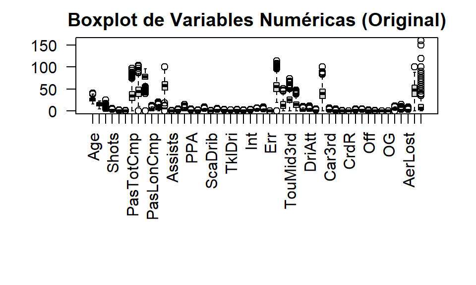

## 9.4 ANEXO 4

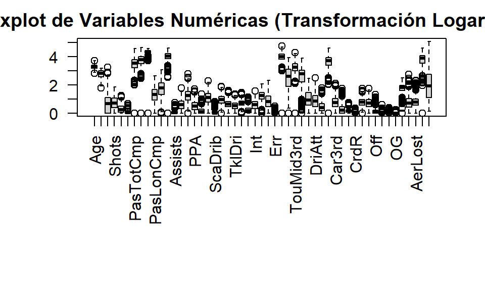

## 9.5 ANEXO 5

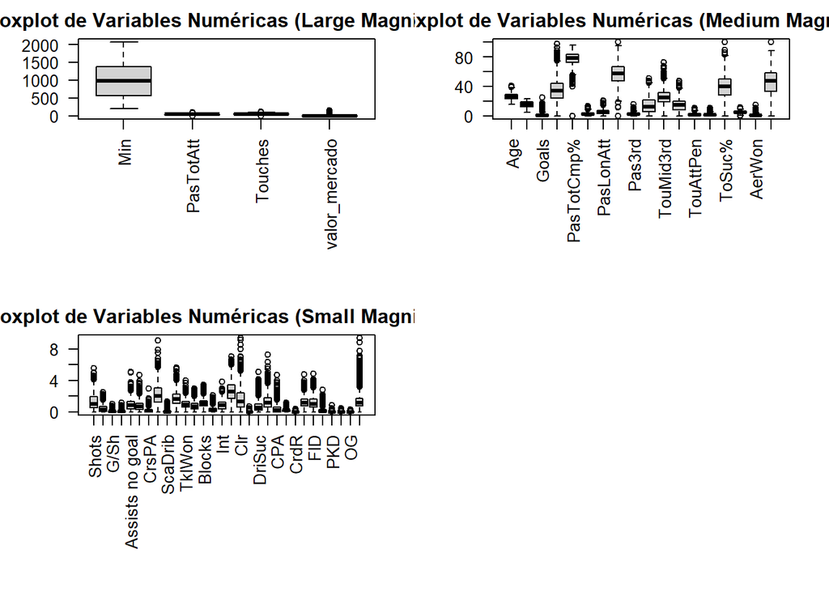

## 9.6 ANEXO 6: Scree plot

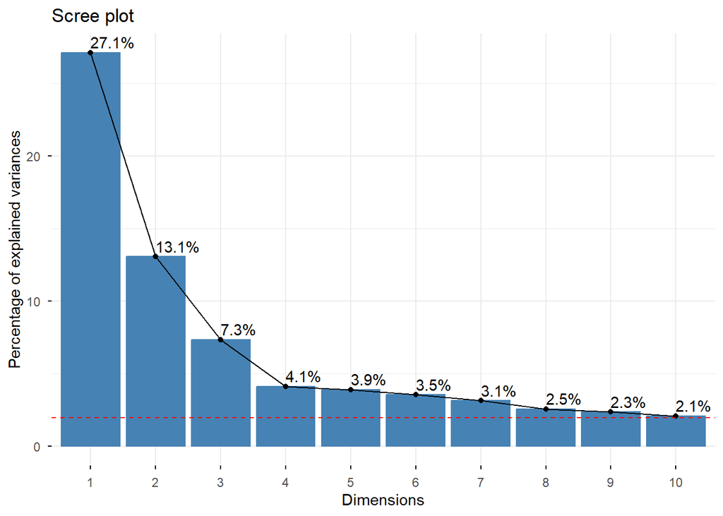

|  | eigenvalue | variance.percent | cumulative.variance.percent |
| --- | --- | --- | --- |
| Dim.1 | 13.8181459 | 27.109465 | 27.10946 |
| Dim.2 | 6.6548926 | 13.056062 | 40.16553 |
| Dim.3 | 3.7298299 | 7.317457 | 47.48298 |
| Dim.4 | 2.0927104 | 4.105635 | 51.58862 |
| Dim.5 | 1.9822541 | 3.888933 | 55.47755 |
| Dim.6 | 1.7989519 | 3.529317 | 59.00687 |
| Dim.7 | 1.5908350 | 3.121018 | 62.12789 |
| Dim.8 | 1.2935701 | 2.537822 | 64.66571 |
| Dim.9 | 1.1943388 | 2.343142 | 67.00885 |
| Dim.10 | 1.0531556 | 2.066159 | 69.07501 |
| Dim.11 | 0.9932224 | 1.948577 | 71.02359 |
| Dim.12 | 0.9710853 | 1.905147 | 72.92874 |
| Dim.13 | 0.9470969 | 1.858085 | 74.78682 |
| Dim.14 | 0.9287190 | 1.822030 | 76.60885 |
| Dim.15 | 0.9131366 | 1.791459 | 78.40031 |
| Dim.16 | 0.8874921 | 1.741148 | 80.14146 |
| Dim.17 | 0.8284092 | 1.625235 | 81.76669 |
| Dim.18 | 0.7587160 | 1.488505 | 83.25520 |
| Dim.19 | 0.7451665 | 1.461923 | 84.71712 |
| Dim.20 | 0.7300275 | 1.432222 | 86.14934 |

## 9.7 ANEXO 7: Gráfico de scores de las componentes 3 y 4

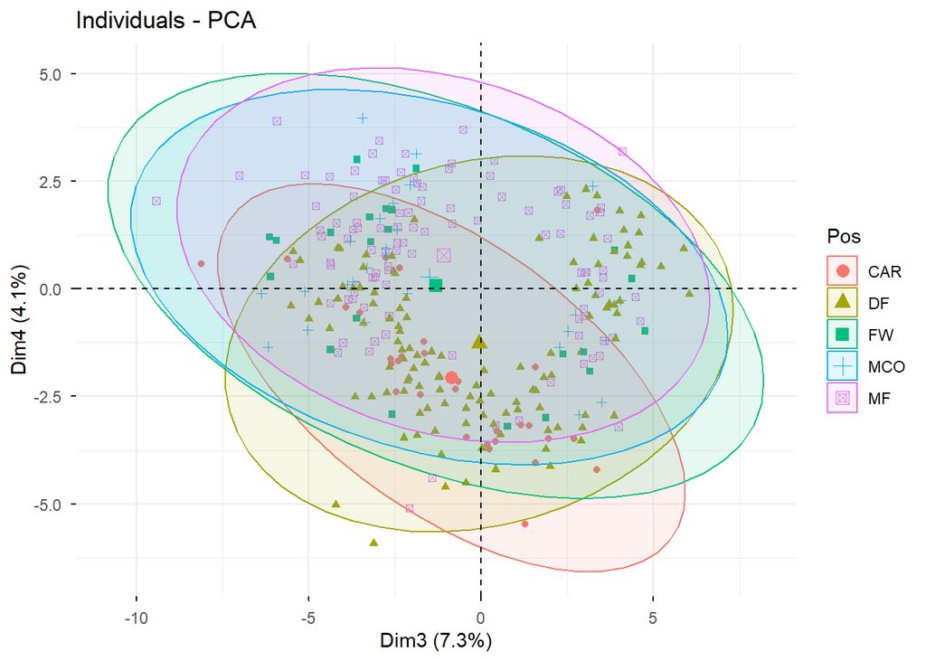

## 9.8 ANEXO 8: T2 de Hotelling

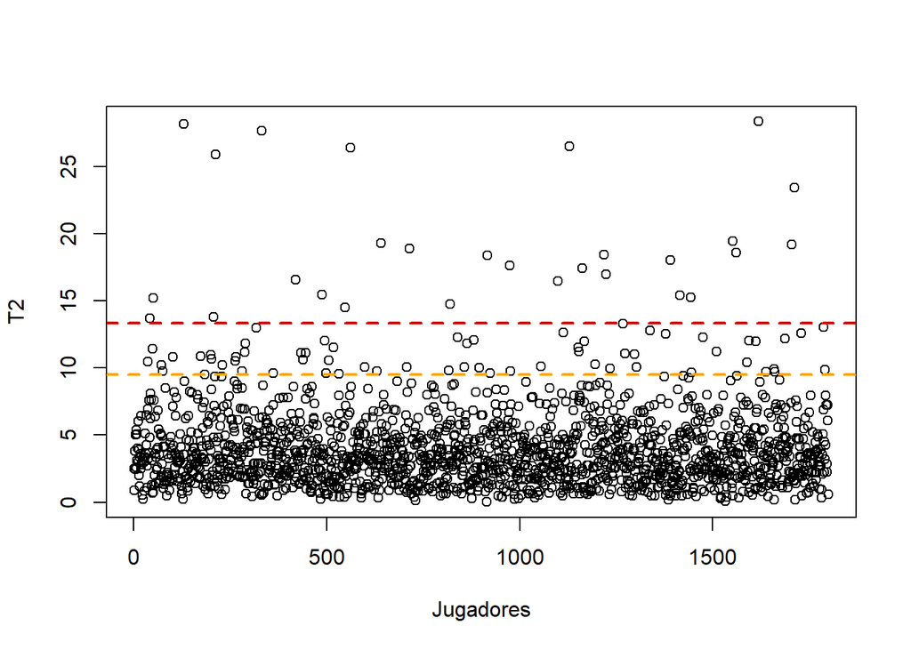

## 9.9 ANEXO 9: Jugadores anómalos

```
## # A tibble: 28 × 1
##    Player
##    <chr>
##  1 Jordi Alba
##  2 Trent Alexander-Arnold
##  3 Carlos Baleba
##  4 Lautaro Blanco
##  5 Jeremie Boga
##  6 Rayan Cherki
##  7 Kevin De Bruyne
##  8 Jeremy Doku
##  9 Nicolás Ezequiel Fernández
## 10 Jacopo Fazzini
## # ℹ 18 more rows
```

## 9.10 ANEXO 10: Anómalo máximo

```
## [1] "1619"
##     Dim.1     Dim.2     Dim.3     Dim.4
##  1.310650  8.678999  1.080826 -5.893963
```

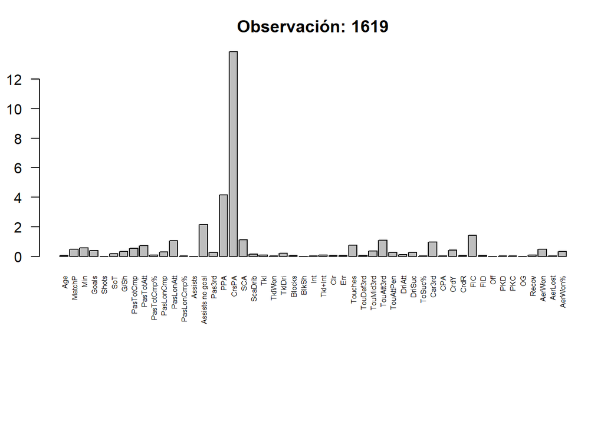

```
## # A tibble: 1 × 2
##   Player        Pos
##   <chr>         <chr>
## 1 Aleksa Terzić DF
```

## 9.11 ANEXO 11: Gráficos de contribución de las variables a las primeras componentes

A continuación, se muestran cuatro gráficos de barras que indican cuánto contribuye cada variable a la construcción de las primeras cuatro componentes principales. Cuanto mayor es la barra, mayor es la influencia de esa variable en la componente correspondiente.

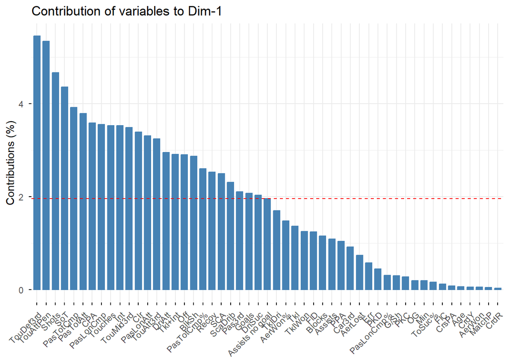

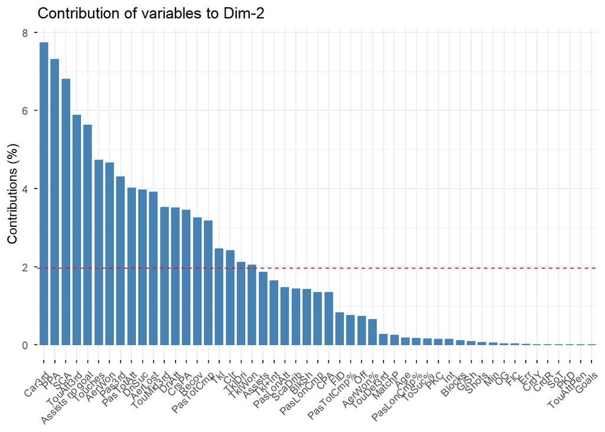

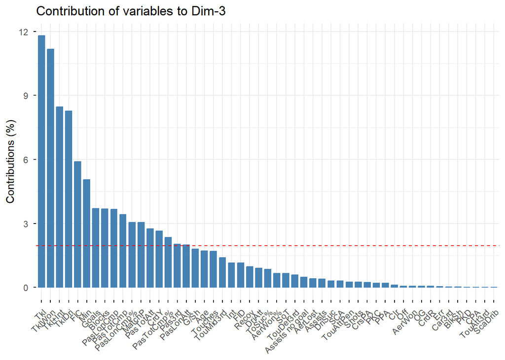

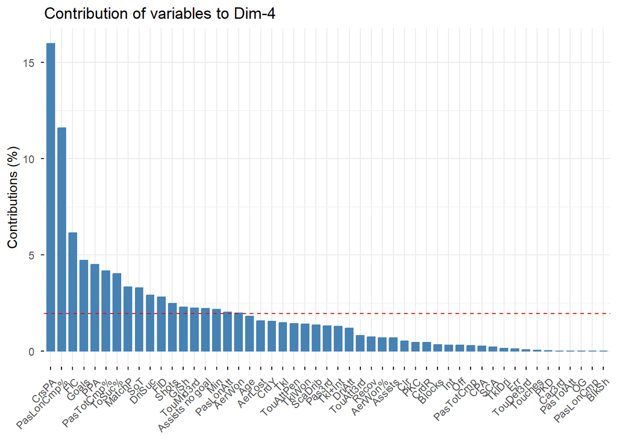